# TITANIC

Meet

2023-03-28

# Working on data

#### Loading required library to work upon data in *R*

```r
library(tidyverse)
library(ggplot2)
library(randomForest)
```

#### Importing data from the train model of *Titanic* dataset

```r
train_df <- read_csv("train.csv", show_col_types = FALSE)
test_df <- read_csv("test.csv", show_col_types = FALSE)
```

Now that we have imported the datasets, lets review them and observe some insights.

#### Review the dataset

```r
head(train_df)
```

```
## # A tibble: 6 × 12
##   PassengerId Survived Pclass Name    Sex     Age SibSp Parch Ticket  Fare Cabin
##         <dbl>    <dbl>  <dbl> <chr>   <chr> <dbl> <dbl> <dbl> <chr>  <dbl> <chr>
## 1           1        0      3 Braund… male     22     1     0 A/5 2…  7.25 <NA>
## 2           2        1      1 Cuming… fema…    38     1     0 PC 17… 71.3  C85
## 3           3        1      3 Heikki… fema…    26     0     0 STON/…  7.92 <NA>
## 4           4        1      1 Futrel… fema…    35     1     0 113803 53.1  C123
## 5           5        0      3 Allen,… male     35     0     0 373450  8.05 <NA>
## 6           6        0      3 Moran,… male     NA     0     0 330877  8.46 <NA>
## # … with 1 more variable: Embarked <chr>
```

```r
glimpse(train_df)
```

```
## Rows: 891
## Columns: 12
## $ PassengerId <dbl> 1, 2, 3, 4, 5, 6, 7, 8, 9, 10, 11, 12, 13, 14, 15, 16, 17,…
## $ Survived    <dbl> 0, 1, 1, 1, 0, 0, 0, 0, 1, 1, 1, 1, 0, 0, 0, 1, 0, 1, 0, 1…
## $ Pclass      <dbl> 3, 1, 3, 1, 3, 3, 1, 3, 3, 2, 3, 1, 3, 3, 3, 2, 3, 2, 3, 3…
## $ Name        <chr> "Braund, Mr. Owen Harris", "Cumings, Mrs. John Bradley (Fl…
## $ Sex         <chr> "male", "female", "female", "female", "male", "male", "mal…
## $ Age         <dbl> 22, 38, 26, 35, 35, NA, 54, 2, 27, 14, 4, 58, 20, 39, 14, …
## $ SibSp       <dbl> 1, 1, 0, 1, 0, 0, 0, 3, 0, 1, 1, 0, 0, 1, 0, 0, 4, 0, 1, 0…
## $ Parch       <dbl> 0, 0, 0, 0, 0, 0, 0, 1, 2, 0, 1, 0, 0, 5, 0, 0, 1, 0, 0, 0…
## $ Ticket      <chr> "A/5 21171", "PC 17599", "STON/O2. 3101282", "113803", "37…
## $ Fare        <dbl> 7.2500, 71.2833, 7.9250, 53.1000, 8.0500, 8.4583, 51.8625,…
## $ Cabin       <chr> NA, "C85", NA, "C123", NA, NA, "E46", NA, NA, NA, "G6", "C…
## $ Embarked    <chr> "S", "C", "S", "S", "S", "Q", "S", "S", "S", "C", "S", "S"…
```

```r
str(train_df)
```

```
## spc_tbl_ [891 × 12] (S3: spec_tbl_df/tbl_df/tbl/data.frame)
##  $ PassengerId: num [1:891] 1 2 3 4 5 6 7 8 9 10 ...
##  $ Survived   : num [1:891] 0 1 1 1 0 0 0 0 1 1 ...
##  $ Pclass     : num [1:891] 3 1 3 1 3 3 1 3 3 2 ...
##  $ Name       : chr [1:891] "Braund, Mr. Owen Harris" "Cumings, Mrs. John Bradley (Florence Briggs Thayer)" "Heikkinen, Miss. Laina" "Futrelle, Mrs. Jacques Heath (Lily May Peel)" ...
##  $ Sex        : chr [1:891] "male" "female" "female" "female" ...
##  $ Age        : num [1:891] 22 38 26 35 35 NA 54 2 27 14 ...
##  $ SibSp      : num [1:891] 1 1 0 1 0 0 0 3 0 1 ...
##  $ Parch      : num [1:891] 0 0 0 0 0 0 0 1 2 0 ...
##  $ Ticket     : chr [1:891] "A/5 21171" "PC 17599" "STON/O2. 3101282" "113803" ...
##  $ Fare       : num [1:891] 7.25 71.28 7.92 53.1 8.05 ...
##  $ Cabin      : chr [1:891] NA "C85" NA "C123" ...
##  $ Embarked   : chr [1:891] "S" "C" "S" "S" ...
##  - attr(*, "spec")=
##   .. cols(
##   ..   PassengerId = col_double(),
##   ..   Survived = col_double(),
##   ..   Pclass = col_double(),
##   ..   Name = col_character(),
##   ..   Sex = col_character(),
##   ..   Age = col_double(),
##   ..   SibSp = col_double(),
##   ..   Parch = col_double(),
##   ..   Ticket = col_character(),
##   ..   Fare = col_double(),
##   ..   Cabin = col_character(),
##   ..   Embarked = col_character()
##   .. )
##  - attr(*, "problems")=<externalptr>
```

```r
summary(train_df)
```

```
##   PassengerId       Survived          Pclass          Name
##  Min.   :  1.0   Min.   :0.0000   Min.   :1.000   Length:891
##  1st Qu.:223.5   1st Qu.:0.0000   1st Qu.:2.000   Class :character
##  Median :446.0   Median :0.0000   Median :3.000   Mode  :character
##  Mean   :446.0   Mean   :0.3838   Mean   :2.309
##  3rd Qu.:668.5   3rd Qu.:1.0000   3rd Qu.:3.000
##  Max.   :891.0   Max.   :1.0000   Max.   :3.000
##
##      Sex                 Age            SibSp           Parch
##  Length:891         Min.   : 0.42   Min.   :0.000   Min.   :0.0000
##  Class :character   1st Qu.:20.12   1st Qu.:0.000   1st Qu.:0.0000
##  Mode  :character   Median :28.00   Median :0.000   Median :0.0000
##                     Mean   :29.70   Mean   :0.523   Mean   :0.3816
##                     3rd Qu.:38.00   3rd Qu.:1.000   3rd Qu.:0.0000
##                     Max.   :80.00   Max.   :8.000   Max.   :6.0000
##                     NA's   :177
##     Ticket               Fare           Cabin             Embarked
##  Length:891         Min.   :  0.00   Length:891         Length:891
##  Class :character   1st Qu.:  7.91   Class :character   Class :character
##  Mode  :character   Median : 14.45   Mode  :character   Mode  :character
##                     Mean   : 32.20
##                     3rd Qu.: 31.00
##                     Max.   :512.33
##
```

```r
summary(test_df)
```

```
##   PassengerId         Pclass          Name               Sex
##  Min.   : 892.0   Min.   :1.000   Length:418         Length:418
##  1st Qu.: 996.2   1st Qu.:1.000   Class :character   Class :character
##  Median :1100.5   Median :3.000   Mode  :character   Mode  :character
##  Mean   :1100.5   Mean   :2.266
##  3rd Qu.:1204.8   3rd Qu.:3.000
##  Max.   :1309.0   Max.   :3.000
##
##       Age            SibSp            Parch           Ticket
##  Min.   : 0.17   Min.   :0.0000   Min.   :0.0000   Length:418
##  1st Qu.:21.00   1st Qu.:0.0000   1st Qu.:0.0000   Class :character
##  Median :27.00   Median :0.0000   Median :0.0000   Mode  :character
##  Mean   :30.27   Mean   :0.4474   Mean   :0.3923
##  3rd Qu.:39.00   3rd Qu.:1.0000   3rd Qu.:0.0000
##  Max.   :76.00   Max.   :8.0000   Max.   :9.0000
##  NA's   :86
##       Fare            Cabin             Embarked
##  Min.   :  0.000   Length:418         Length:418
##  1st Qu.:  7.896   Class :character   Class :character
##  Median : 14.454   Mode  :character   Mode  :character
##  Mean   : 35.627
##  3rd Qu.: 31.500
##  Max.   :512.329
##  NA's   :1
```

We can see in the summary that **177** missing values of Age is there in the *train_df* dataset but Age is an important factor in the survival on *Titanic*.

### Cleaning Data

#### Missing Values

Now lets make the **missing values** and the **space values** if any into **NA** to avoid any future confusions.  
We will create a copy of *train_df* and name it *train_df2*

```r
train_df2 <- train_df
train_df2[train_df2=="" | train_df2==" "] <- NA
```

Lets do the same for *test_df* dataset.

```r
test_df2 <- test_df
test_df2[test_df2=="" | test_df2==" "] <- NA
```

For future convenience, let’s combine the dataset but the main problem is that the *test* dataset don’t contain the column **Survived**.  
So we are going to bind the column with values **NA**.

```r
test_df2 <- cbind(test_df2, Survived = NA)
```

Now that we have added the column to the dataset, both the datasets contains same columns so now we will bind the rows to combine both data.

```r
alldata <- rbind(train_df2, test_df2)
```

Take a look at the summary of the combined data

```r
summary(alldata)
```

```
##   PassengerId      Survived          Pclass          Name
##  Min.   :   1   Min.   :0.0000   Min.   :1.000   Length:1309
##  1st Qu.: 328   1st Qu.:0.0000   1st Qu.:2.000   Class :character
##  Median : 655   Median :0.0000   Median :3.000   Mode  :character
##  Mean   : 655   Mean   :0.3838   Mean   :2.295
##  3rd Qu.: 982   3rd Qu.:1.0000   3rd Qu.:3.000
##  Max.   :1309   Max.   :1.0000   Max.   :3.000
##                 NA's   :418
##      Sex                 Age            SibSp            Parch
##  Length:1309        Min.   : 0.17   Min.   :0.0000   Min.   :0.000
##  Class :character   1st Qu.:21.00   1st Qu.:0.0000   1st Qu.:0.000
##  Mode  :character   Median :28.00   Median :0.0000   Median :0.000
##                     Mean   :29.88   Mean   :0.4989   Mean   :0.385
##                     3rd Qu.:39.00   3rd Qu.:1.0000   3rd Qu.:0.000
##                     Max.   :80.00   Max.   :8.0000   Max.   :9.000
##                     NA's   :263
##     Ticket               Fare            Cabin             Embarked
##  Length:1309        Min.   :  0.000   Length:1309        Length:1309
##  Class :character   1st Qu.:  7.896   Class :character   Class :character
##  Mode  :character   Median : 14.454   Mode  :character   Mode  :character
##                     Mean   : 33.295
##                     3rd Qu.: 31.275
##                     Max.   :512.329
##                     NA's   :1
```

### Observing Data

Now we observed that the there is one missing value in *Fare* column. So let’s observe the profile of the row to fill the data.

```r
alldata %>%
  filter(is.na(Fare))
```

```
## # A tibble: 1 × 12
##   PassengerId Survived Pclass Name    Sex     Age SibSp Parch Ticket  Fare Cabin
##         <dbl>    <dbl>  <dbl> <chr>   <chr> <dbl> <dbl> <dbl> <chr>  <dbl> <chr>
## 1        1044       NA      3 Storey… male   60.5     0     0 3701      NA <NA>
## # … with 1 more variable: Embarked <chr>
```

#### Assigning suitable value in Fare

```r
fare_df <- alldata %>%
  filter(Embarked=="S", Sex=="male", Pclass==3, Age>=55)
head(fare_df)
```

```
## # A tibble: 5 × 12
##   PassengerId Survived Pclass Name    Sex     Age SibSp Parch Ticket  Fare Cabin
##         <dbl>    <dbl>  <dbl> <chr>   <chr> <dbl> <dbl> <dbl> <chr>  <dbl> <chr>
## 1          95        0      3 Coxon,… male   59       0     0 364500  7.25 <NA>
## 2         153        0      3 Meo, M… male   55.5     0     0 A.5. …  8.05 <NA>
## 3         327        0      3 Nysvee… male   61       0     0 345364  6.24 <NA>
## 4         852        0      3 Svenss… male   74       0     0 347060  7.78 <NA>
## 5        1044       NA      3 Storey… male   60.5     0     0 3701   NA    <NA>
## # … with 1 more variable: Embarked <chr>
```

From the data we can get idea about the **Median** of the data.  
Now let’s check and verify the data that is there any variation in Fare prices in *Pclass=3*.

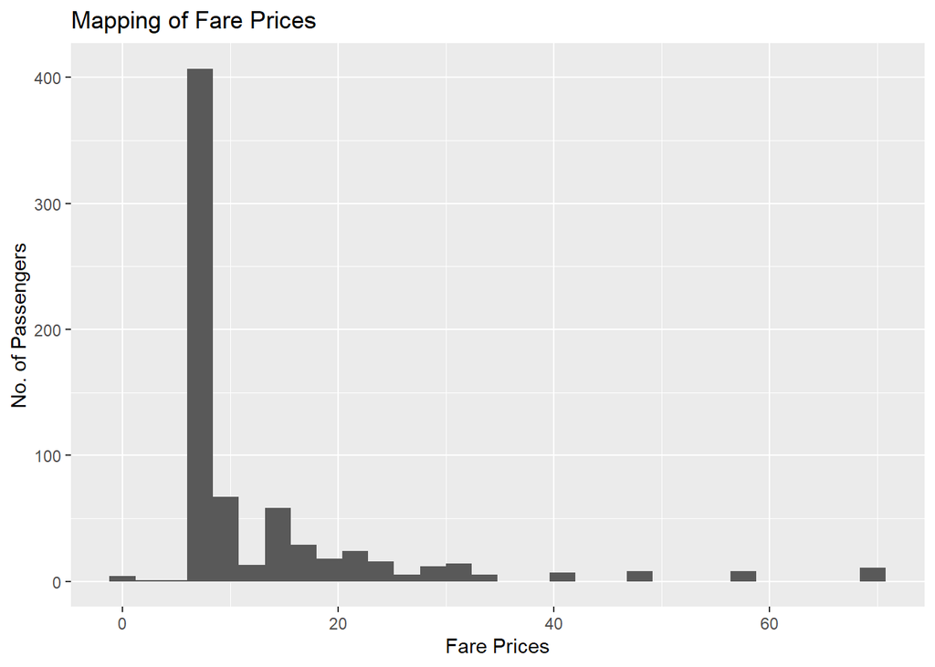

```r
ggplot(data=alldata %>% filter(Pclass==3))+
  geom_histogram(mapping=aes(x=Fare))+
  labs(x="Fare Prices", y="No. of Passengers", title="Mapping of Fare Prices")
```

It’s around the **median** which is obtained by the filtered data.  
Now lets calculate the median and assign the value to **NA**.

```r
alldata$Fare[is.na(alldata$Fare)] <- median(fare_df$Fare, na.rm=T)

alldata %>%
  filter(Age==60.5)
```

```
## # A tibble: 1 × 12
##   PassengerId Survived Pclass Name    Sex     Age SibSp Parch Ticket  Fare Cabin
##         <dbl>    <dbl>  <dbl> <chr>   <chr> <dbl> <dbl> <dbl> <chr>  <dbl> <chr>
## 1        1044       NA      3 Storey… male   60.5     0     0 3701    7.51 <NA>
## # … with 1 more variable: Embarked <chr>
```

**NOTE**: *na.rm* is used to remove the missing values from the input vector.

#### Converting *Sex* column into numericals

Let’s check the **NA** values in the *Sex* column if any.

```r
table(is.na(alldata$Sex))
```

```
##
## FALSE
##  1309
```

There is no **NA** values.  
Now, assign the value **1** for *male* and **0** for *female*.

```r
alldata$Sex[alldata$Sex == "male"] <- 1
alldata$Sex[alldata$Sex == "female"] <- 0
head(alldata)
```

```
## # A tibble: 6 × 12
##   PassengerId Survived Pclass Name    Sex     Age SibSp Parch Ticket  Fare Cabin
##         <dbl>    <dbl>  <dbl> <chr>   <chr> <dbl> <dbl> <dbl> <chr>  <dbl> <chr>
## 1           1        0      3 Braund… 1        22     1     0 A/5 2…  7.25 <NA>
## 2           2        1      1 Cuming… 0        38     1     0 PC 17… 71.3  C85
## 3           3        1      3 Heikki… 0        26     0     0 STON/…  7.92 <NA>
## 4           4        1      1 Futrel… 0        35     1     0 113803 53.1  C123
## 5           5        0      3 Allen,… 1        35     0     0 373450  8.05 <NA>
## 6           6        0      3 Moran,… 1        NA     0     0 330877  8.46 <NA>
## # … with 1 more variable: Embarked <chr>
```

## Name

### Separating Title

Lets take a look at the sample of the 30 *Name* column to draw the conclusions about professional title they have.

```r
sample(alldata$Name, 30)
```

```
##  [1] "O'Donoghue, Ms. Bridget"
##  [2] "Lefebre, Master. Henry Forbes"
##  [3] "Giglio, Mr. Victor"
##  [4] "Asplund, Master. Filip Oscar"
##  [5] "Loring, Mr. Joseph Holland"
##  [6] "Hee, Mr. Ling"
##  [7] "Abelson, Mr. Samuel"
##  [8] "Cann, Mr. Ernest Charles"
##  [9] "Candee, Mrs. Edward (Helen Churchill Hungerford)"
## [10] "Johnson, Miss. Eleanor Ileen"
## [11] "Osman, Mrs. Mara"
## [12] "Laleff, Mr. Kristo"
## [13] "Ostby, Miss. Helene Ragnhild"
## [14] "Bazzani, Miss. Albina"
## [15] "Windelov, Mr. Einar"
## [16] "Ringhini, Mr. Sante"
## [17] "Attalah, Mr. Sleiman"
## [18] "Beane, Mr. Edward"
## [19] "Albimona, Mr. Nassef Cassem"
## [20] "Touma, Mrs. Darwis (Hanne Youssef Razi)"
## [21] "Sincock, Miss. Maude"
## [22] "Nasser, Mr. Nicholas"
## [23] "Moubarek, Mrs. George (Omine Amenia\" Alexander)\""
## [24] "Carlsson, Mr. Frans Olof"
## [25] "Humblen, Mr. Adolf Mathias Nicolai Olsen"
## [26] "O'Brien, Mrs. Thomas (Johanna \"Hannah\" Godfrey)"
## [27] "Nilsson, Miss. Helmina Josefina"
## [28] "Mangiavacchi, Mr. Serafino Emilio"
## [29] "Lundahl, Mr. Johan Svensson"
## [30] "Kimball, Mr. Edwin Nelson Jr"
```

Let’s separate the *Professional_title* data from *Name* column.

```r
alldata <- alldata %>%
  separate(Name, into=c('name2', 'name3'), sep=', ')
```

```r
alldata <- alldata %>%
  separate(name3, into=c('Professional_title', 'name4'), sep='. ')
alldata <- alldata %>%
  select(-name2,-name4)
```

### Mapping

Check for the **NA** if any,

```r
table(is.na(alldata$Professional_title))
```

```
##
## FALSE
##  1309
```

As there is no **NA** so lets make a plot of total counts of all titles.

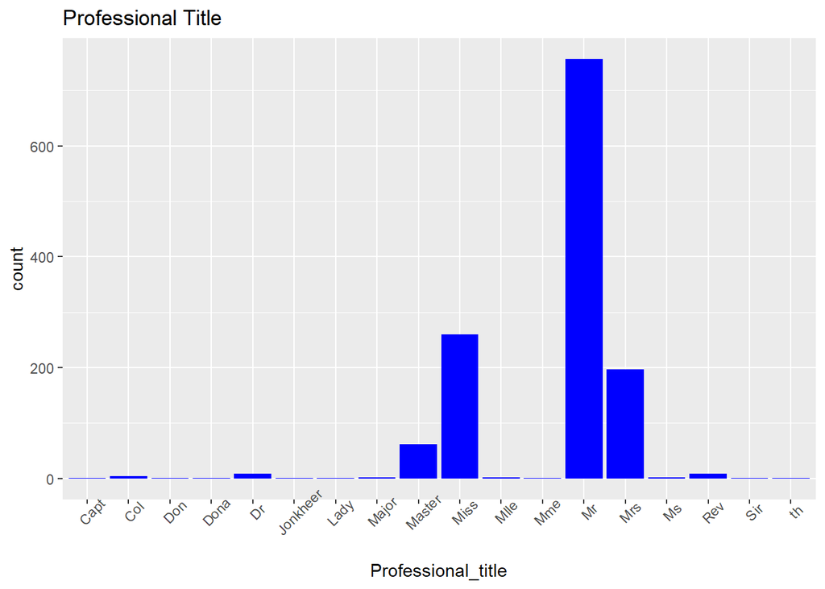

```r
ggplot(data=alldata) +
  geom_bar(mapping=aes(x=Professional_title), fill='blue') +
  labs(title="Professional Title") +
  theme(axis.text.x = element_text(angle=45))
```

Now, we observe the popular title to have the idea about Survival for different title holders.

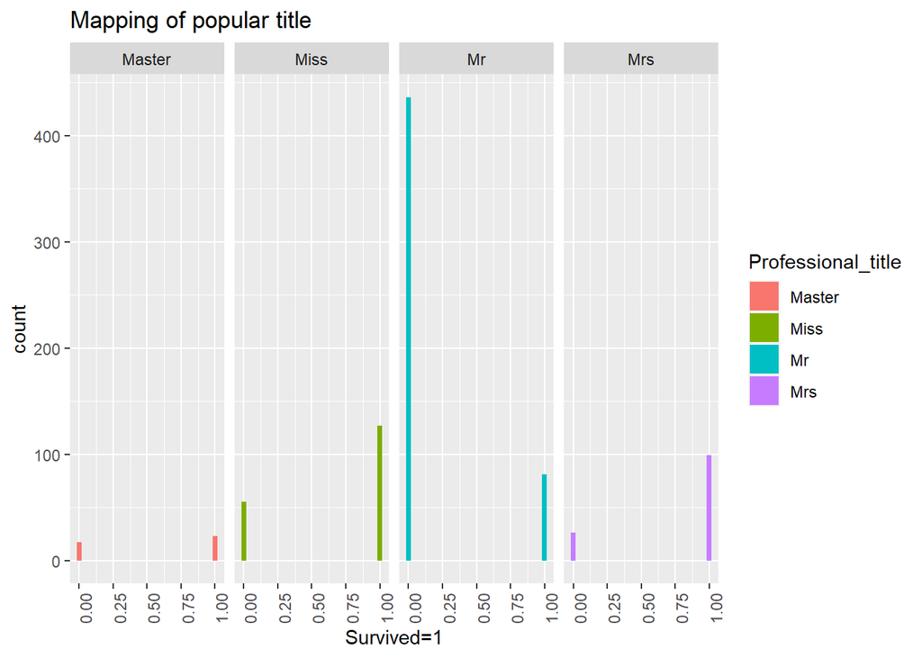

```r
ggplot(data = alldata %>% filter(Professional_title %in% c("Mr", "Miss", "Mrs", "Master"))) +
  geom_histogram(mapping=aes(x=Survived, fill=Professional_title))+
  facet_grid(~Professional_title)+
  labs(title="Mapping of popular title", x="Survived=1")+
  theme(axis.text.x=element_text(angle=90))
```

### Converting the rare titles into popular ones

Let’s observe the data of *male title* and draw some insights about them.

```r
alldata %>%
  filter(Professional_title %in% c("Capt", "Col", "Don", "Dr", "Jonkheer", "Major", "Rev", "Sir"))
```

```
## # A tibble: 26 × 12
##    PassengerId Survi…¹ Pclass Profe…² Sex     Age SibSp Parch Ticket  Fare Cabin
##          <dbl>   <dbl>  <dbl> <chr>   <chr> <dbl> <dbl> <dbl> <chr>  <dbl> <chr>
##  1          31       0      1 Don     1        40     0     0 PC 17…  27.7 <NA>
##  2         150       0      2 Rev     1        42     0     0 244310  13   <NA>
##  3         151       0      2 Rev     1        51     0     0 S.O.P…  12.5 <NA>
##  4         246       0      1 Dr      1        44     2     0 19928   90   C78
##  5         250       0      2 Rev     1        54     1     0 244252  26   <NA>
##  6         318       0      2 Dr      1        54     0     0 29011   14   <NA>
##  7         399       0      2 Dr      1        23     0     0 244278  10.5 <NA>
##  8         450       1      1 Major   1        52     0     0 113786  30.5 C104
##  9         537       0      1 Major   1        45     0     0 113050  26.6 B38
## 10         600       1      1 Sir     1        49     1     0 PC 17…  56.9 A20
## # … with 16 more rows, 1 more variable: Embarked <chr>, and abbreviated
## #   variable names ¹Survived, ²Professional_title
```

Let’s rename the titles like *Capt*, *Col*, *Don*, *Dr*, *Jonkheer*, *Major*, *Rev*, *Sir* into *Mr* for making our life easy as there is no important insight and No. of Survived are equivalent to *Mr*….

```r
alldata$Professional_title[alldata$Professional_title %in% c("Capt", "Col", "Don", "Dr", "Jonkheer", "Major", "Rev", "Sir")] <- "Mr"
```

Do the same process with *female title*.

```r
alldata %>%
  filter(Professional_title %in% c("Dona", "Lady", "Mlle", "Mme", "th"))
```

```
## # A tibble: 6 × 12
##   PassengerId Survived Pclass Profe…¹ Sex     Age SibSp Parch Ticket  Fare Cabin
##         <dbl>    <dbl>  <dbl> <chr>   <chr> <dbl> <dbl> <dbl> <chr>  <dbl> <chr>
## 1         370        1      1 Mme     0        24     0     0 PC 17…  69.3 B35
## 2         557        1      1 Lady    0        48     1     0 11755   39.6 A16
## 3         642        1      1 Mlle    0        24     0     0 PC 17…  69.3 B35
## 4         711        1      1 Mlle    0        24     0     0 PC 17…  49.5 C90
## 5         760        1      1 th      0        33     0     0 110152  86.5 B77
## 6        1306       NA      1 Dona    0        39     0     0 PC 17… 109.  C105
## # … with 1 more variable: Embarked <chr>, and abbreviated variable name
## #   ¹Professional_title
```

Let’s rename the titles like *Dona*, *Lady*, *Mlle*, *Mme*, *th* into *Mrs* and *Ms* into *Miss* as Ms is basically the short of Miss.

```r
alldata$Professional_title[alldata$Professional_title %in% c("Dona", "Lady", "Mlle", "Mme", "th")] <- "Mrs"
```

```r
alldata$Professional_title[alldata$Professional_title == "Ms"] <- "Miss"
```

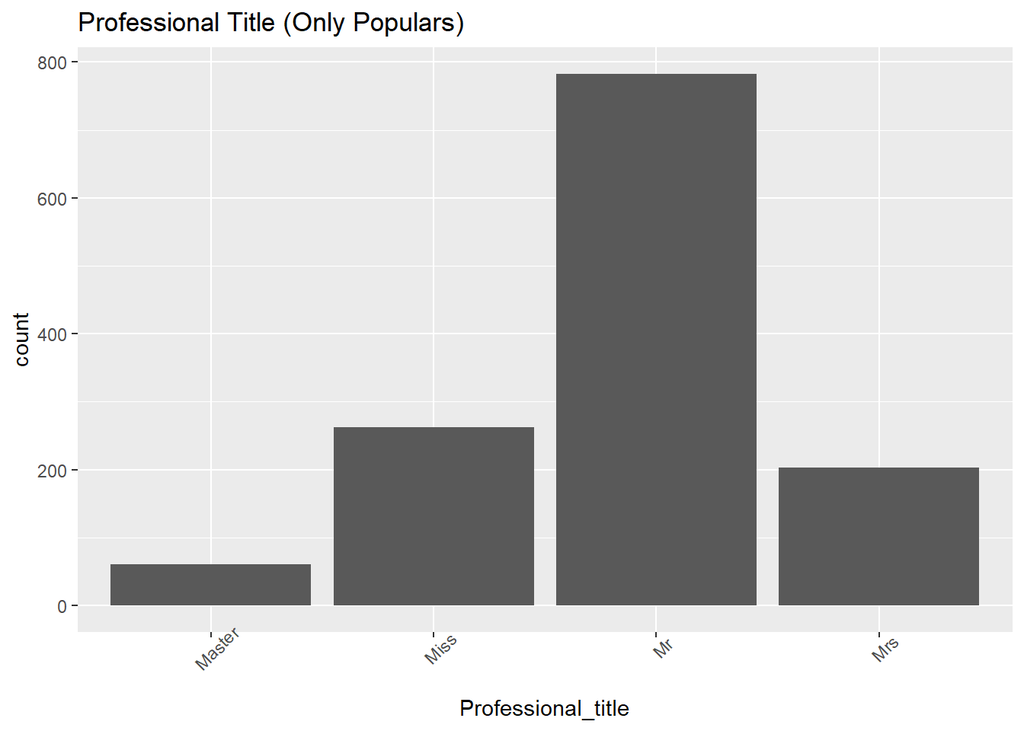

```r
ggplot(data=alldata) +
  geom_bar(mapping=aes(x=Professional_title)) +
  labs(title="Professional Title (Only Populars)") +
  theme(axis.text.x = element_text(angle=45))
```

## Embarked

First of all see the **NA** value if any in the *Embarked* column

```r
table(is.na(alldata$Embarked))
```

```
##
## FALSE  TRUE
##  1307     2
```

### Observe the data

Review the both rows and draw the conclusion to fill the missing values.

```r
alldata %>%
  filter(is.na(Embarked))
```

```
## # A tibble: 2 × 12
##   PassengerId Survived Pclass Profe…¹ Sex     Age SibSp Parch Ticket  Fare Cabin
##         <dbl>    <dbl>  <dbl> <chr>   <chr> <dbl> <dbl> <dbl> <chr>  <dbl> <chr>
## 1          62        1      1 Miss    0        38     0     0 113572    80 B28
## 2         830        1      1 Mrs     0        62     0     0 113572    80 B28
## # … with 1 more variable: Embarked <chr>, and abbreviated variable name
## #   ¹Professional_title
```

We can see that both have *Pclass*=1, same *Ticket* number, *Fare*=80, same *Cabin* and both *female*.

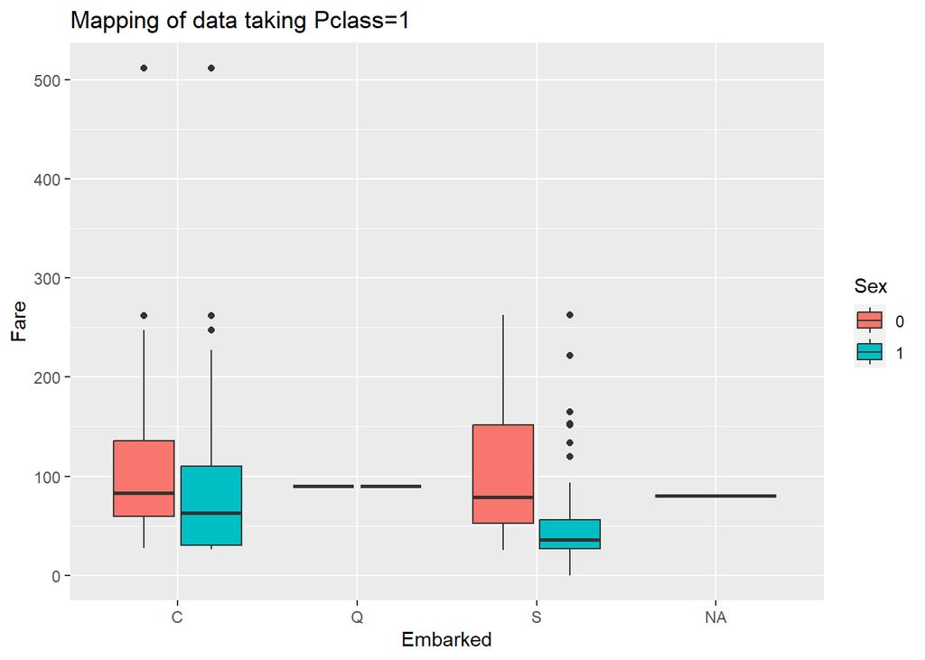

```r
ggplot(alldata %>% filter(Pclass==1)) +
  geom_boxplot(mapping=aes(x=Embarked, y=Fare, fill=Sex)) +
  labs(title="Mapping of data taking Pclass=1")
```

With the help of plot we can conclude that missing value is the **C**.

### Filling the missing value

```r
alldata$Embarked[is.na(alldata$Embarked)] <- "C"
```

## Age

Let’s see the **NA** value if any in the *Age* column.

```r
table(is.na(alldata$Age))
```

```
##
## FALSE  TRUE
##  1046   263
```

Let’ draw a plot to have a better idea about *age* and *title* as they can have some relationship to fill our missing.

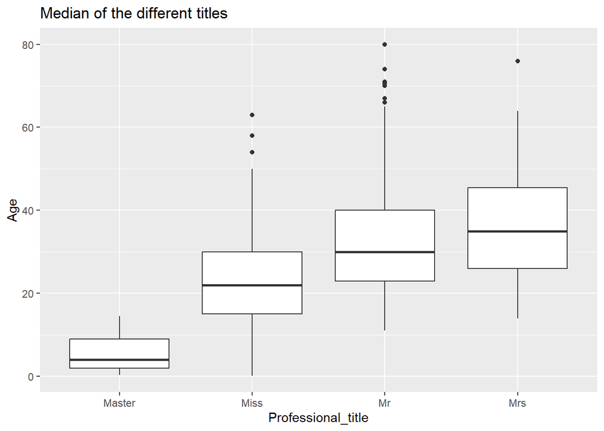

```r
ggplot(alldata) +
  geom_boxplot(mapping=aes(x=Professional_title, y=Age)) +
  labs(title = "Median of the different titles")
```

Let’s take the **median** of the respective *Professional_title* and fill the missing value respectively.

### Filling Master title

```r
master_df <- alldata %>%
  filter(Professional_title=="Master")
master_df$Age[is.na(master_df$Age)] <- median(master_df$Age, na.rm=T)
```

### Filling Miss title

```r
miss_df <- alldata %>%
  filter(Professional_title=="Miss")
miss_df$Age[is.na(miss_df$Age)] <- median(miss_df$Age, na.rm=T)
```

### Filling Mr title

```r
mr_df <- alldata %>%
  filter(Professional_title=="Mr")
mr_df$Age[is.na(mr_df$Age)] <- median(mr_df$Age, na.rm=T)
```

### Filling Mrs title

```r
mrs_df <- alldata %>%
  filter(Professional_title=="Mrs")
mrs_df$Age[is.na(mrs_df$Age)] <- median(mrs_df$Age, na.rm=T)
```

### Binding

Now, merge the data into again *alldata* dataset.

```r
alldata <- rbind(master_df, miss_df, mr_df, mrs_df)
alldata <- alldata %>%
  arrange(PassengerId)
```

## Ticket

Check the **NA** if any,

```r
table(is.na(alldata$Ticket))
```

```
##
## FALSE
##  1309
```

Take the sample and observe the data of *ticket* column.

```r
sample(alldata$Ticket, 30)
```

```
##  [1] "7540"              "248746"            "345572"
##  [4] "113038"            "349254"            "350025"
##  [7] "SC/AH 3085"        "13507"             "STON/O 2. 3101275"
## [10] "PC 17595"          "113781"            "11753"
## [13] "362316"            "2908"              "1601"
## [16] "PC 17596"          "363272"            "13502"
## [19] "347070"            "PC 17612"          "113789"
## [22] "347088"            "113776"            "111369"
## [25] "2648"              "7598"              "17474"
## [28] "111320"            "350054"            "239865"
```

Can’t have any relevance to the survival of the passengers, so decided to remove the column

```r
alldata <- alldata %>%
  select(-Ticket)
```

## Pclass

Check the **NA** if any,

```r
table(is.na(alldata$Pclass))
```

```
##
## FALSE
##  1309
```

## SibSp

Check the **NA** if any,

```r
table(is.na(alldata$SibSp))
```

```
##
## FALSE
##  1309
```

## Parch

Check the **NA** if any,

```r
table(is.na(alldata$Parch))
```

```
##
## FALSE
##  1309
```

## Cabin

Check the **NA** if any,

```r
table(is.na(alldata$Cabin))
```

```
##
## FALSE  TRUE
##   295  1014
```

As there are many empty cells in the *Cabin* column so best possible solution is to drop the column only.

```r
alldata <- alldata %>%
  select(-Cabin)
```

# Appling Model into our cleaned data

### Let’s apply a randomForest

Honestly didn’t know the shit about this models right now :(  
but let’s apply to our data.

```r
i <- is.na(alldata$Survived)
myforest <- randomForest(data=alldata[!i,], Survived ~ Pclass + Age + SibSp + Parch + Fare + Embarked + Sex + Professional_title,
                             ntree=10000, sampsize = 400, mtry=4)
```

Now let’s look the **model** works decent or not…

```r
table(round(predict(myforest, newdata=alldata[!i,])) == alldata[!i,]$Survived)
```

```
##
## FALSE  TRUE
##    90   801
```

Add the predictions into our data for submissions

```r
alldata$forestpred <- round(predict(myforest, newdata=alldata))
rm(myforest)
```

Export the **.csv** file

```r
write.csv(alldata %>%
  filter(PassengerId %in% c(892:1310)) %>%
  select(PassengerId, forestpred) %>%
  rename(Survived = forestpred), "submission.csv")
```

Now deleted the No. column in the Excel manually and submitted the data……..**0.77272**  
Great for my first Project.

Thank you